# Tvyal Newsletter

2024-11-18

*English summary below.*

Հարգելի գործընկեր,

## [🎭🇦🇲💸️ Վտանգավոր թվեր․ Հայաստանի տնտեսական «հրաշքի» մութ կողմը](https://www.tvyal.com/newsletter/2024/2024_11_18)

### **Հայաստանի ֆիսկալ մարտահրավերները և դրանց ազդեցությունը երկրի ապագայի վրա**

### Թվերը չեն խաբում

Գծապատկեր 1

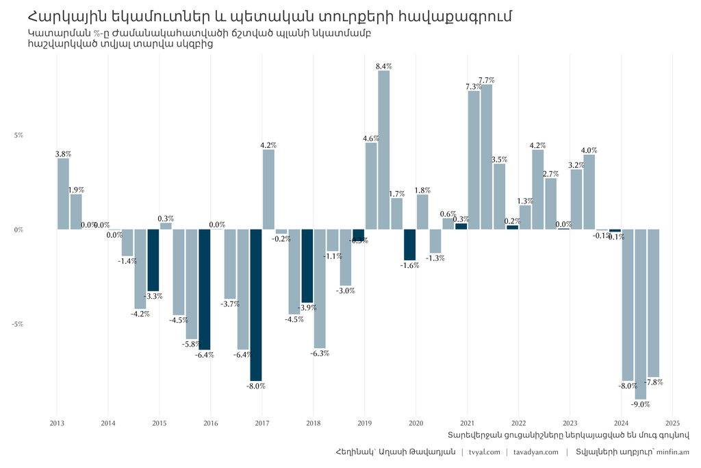

«Երբ տեսնում ես հարկերի հավաքագրման նման կտրուկ փոփոխություն, դա սովորաբար վկայում է տնտեսության մեջ առկա ավելի խորը կառուցվածքային խնդիրների մասին», - նշում է տարածաշրջանին քաջածանոթ ավագ տնտեսական վերլուծաբանը։ Կառավարության տվյալները ցույց են տալիս, որ սա միանգամյա խնդիր չէ։ Միտումը սկսվել է 2024թ․ սկզբում և շարունակվում է, ինչը վկայում է ոչ թե ժամանակավոր, այլ համակարգային գործոնների առկայության մասին։

Ժամանակացույցը հատկապես անհարմար է։ Հայաստանի տնտեսական աճի ցուցանիշները տպավորիչ են եղել՝ 12.6% 2022 թվականին, ինչը շատերին դրդել է խոսել «տնտեսական հրաշքի» մասին։ Սակայն, ինչպես հաճախ է պատահում հրաշքների հետ, ավելի մանրակրկիտ ուսումնասիրությունը բացահայտում է ավելի բարդ իրականություն։ Աճը հիմնականում պայմանավորված է եղել արտաքին գործոններով՝ ռուսական կապիտալի ներհոսքով, ոսկու վերաարտահանմամբ և պոտենցիալ անկայուն ծառայությունների ոլորտի աճով։

Պատկերացրեք տուն՝ թարմ ներկված, բայց ճռճռացող հիմքերով։ Փայլուն արտաքինը՝ տպավորիչ ՀՆԱ-ի աճը, թաքցնում է կառուցվածքային թուլությունները, որոնք այժմ դրսևորվում են հարկերի հավաքագրման ցուցանիշներում։ Կառավարության սեփական վերլուծությունը վկայում է, որ 4.5%-ը ավելի իրատեսական է որպես երկարաժամկետ աճի տեմպ՝ շատ ավելի ցածր ներկայիս ցուցանիշներից։

> **Այս նյութին առնչվող հրապարակումներ**

> [🚨📉🕵 Քողարկված անկում. Ինչո՞վ է ապրում Հայաստանի տնտեսությունը](https://www.tvyal.com/newsletter/2024/2024_09_30)

> [💸🔚🏦 Կապիտալի ներհոսքից մինչև արտահոսք](https://www.tvyal.com/newsletter/2024/2024_09_16)

> [🧮⏳🎲 Հայաստանը հարկում է ժամանակը](https://www.tvyal.com/newsletter/2024/2024_08_02)

> [💰🚧⚖️ Պետական պարտքի ճոճանակ․ Առաջին անգամ ներքին պարտքը գերազանցում է արտաքինը](https://www.tvyal.com/newsletter/2024/2024_06_28)

> [🆘🇦🇲🧑🏼‍💻 SOS ՀՀ ՏՏ. ռազմավարական առաջնահերթությունից մինչև հնարավոր անկում](https://www.tvyal.com/newsletter/2024/2024_08_19)

> [Վերլուծությունների ամբողջական ցանկը այստեղ](https://www.tvyal.com/newsletter)

### Երկու տնտեսությունների պատմություն

Գծապատկեր 2

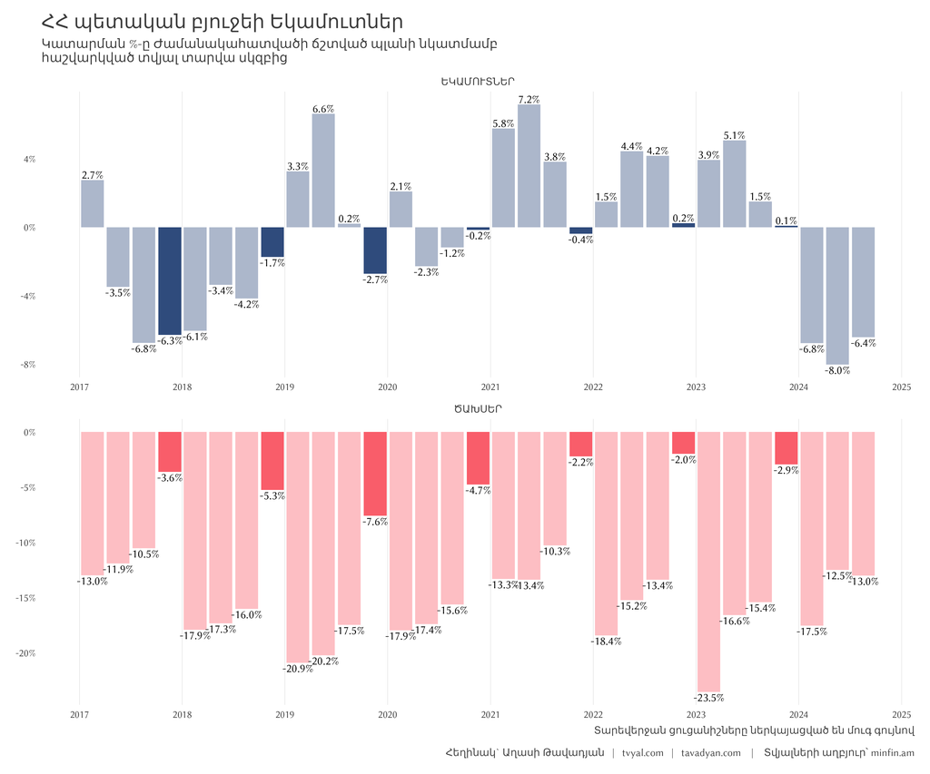

Աճող տնտեսության և նվազող հարկային եկամուտների միջև հակասությունը մատնանշում է մի հետաքրքիր տնտեսական երևույթ՝ ինչ է տեղի ունենում, երբ տնտեսությունն աճում է այնպիսի ուղիներով, որոնք չեն վերածվում կայուն հարկային բազայի։ Հայաստանի վերջին շրջանի աճը խիստ կենտրոնացված է եղել այն ոլորտներում, որոնք կա՛մ օգտվում են հարկային արտոնություններից, կա՛մ դժվար են արդյունավետ հարկման ենթարկվում, ինչպես քննարկվել է մեր նախորդ վերլուծությունում [💸🔚🏦 Կապիտալի հոսքերը և տնտեսական հրաշքները](https://www.tvyal.com/newsletter/2024/2024_09_16)։

Վերցնենք, օրինակ, բանկային հատվածը։ 2022 թվականին հայկական բանկերի փոխանցումներն աճել են 2.5 անգամ՝ 2.1 միլիարդ դոլարից հասնելով 5.2 միլիարդի, հիմնականում ռուսական ներհոսքերի շնորհիվ։ Թեև սա ստեղծեց ժամանակավոր բում, այն չկառուցեց երկարատև տնտեսական ենթակառուցվածք։ Սա նման է մեծ ժառանգություն ստանալուն՝ հիանալի է անմիջական ծախսերի համար, բայց չի հանդիսանում երկարաժամկետ եկամտի հուսալի աղբյուր։

Կապիտալի հոսքերի պատմությունն ունի ևս մեկ ուշագրավ դրվագ։ Ներհոսքերի սկզբնական ալիքը սկսել է հակառակվել, զգալի արտահոսքերով դեպի այնպիսի ուղղություններ, ինչպիսին է ԱՄԷ-ն։ Այս օրինաչափությունը ենթադրում է, որ Հայաստանը ավելի շուտ ծառայել է որպես տարանցիկ կետ, քան վերջնական նպատակակետ այս կապիտալի մեծ մասի համար՝ ևս մեկ պատճառ, թե ինչու տպավորիչ աճի ցուցանիշները չեն վերածվել կայուն հարկային եկամուտների։

Անշարժ գույքի և ֆինանսական ծառայությունների ոլորտները՝ աճի երկու այլ հիմնական շարժիչներ, ունեն նմանատիպ բնութագրեր. դրանք օգտվել են կապիտալի ներհոսքից, բայց պարտադիր չէ, որ ստեղծեն այն տեսակի լայնածավալ տնտեսական գործունեություն, որը գեներացնում է կայուն հարկային եկամուտներ։ Դա նման է երեկույթի, որը հիանալի է երևում լուսանկարներում, բայց քիչ երկարատև ազդեցություն է թողնում։

### Տեխնոլոգիական պատմությունը և վաղվա մարտահրավերները

Աղյուսակ 1

ՀՀ ԲՏԱ նախարարության կողմից իրականացված ծրագրերը

2024թ. ինն ամիսներին (մլն դրամ)

|  | 2023թ. ինն ամիսների փաստ | 2024թ. ինն ամիսների ճշտված պլան | 2024թ. ինն ամիսների փաստ | Կատարո-ղականն ինն ամիսների ճշտված պլանի նկատմամբ (%) | 2024թ. ինն ամիսները 2023թ. ինն ամիսների նկատմամբ (%) | 2024թ. և 2023թ. տարբե-րությունը |
| --- | --- | --- | --- | --- | --- | --- |
| ԸՆԴԱՄԵՆԸ | 17,398.1 | 13,388.8 | 7,825.6 | 58.4% | 45.0% | −9,572.5 |
| Բարձր տեխնոլոգիական արդյունաբերության էկոհամակարգի և շուկայի զարգացման ծրագիր | 15,664.1 | 8,631.2 | 6,034.7 | 69.9% | 38.5% | −9,629.5 |
| Թվային փոխակերպման գործընթացի իրականացում | 0.0 | 1,974.8 | 51.8 | 2.6% | - | 51.8 |
| Այլ ծրագրեր | 1,733.9 | 2,782.8 | 1,739.1 | 62.5% | 100.3% | 5.1 |

Թերևս արտաքինի և իրականության միջև անջրպետը ոչ մի տեղ այնքան ակնառու չէ, որքան Հայաստանի տեխնոլոգիական ոլորտում։ Մի ժամանակ հռչակված որպես երկրի կայուն աճի ուղեգիր՝ ոլորտն այժմ ցուցաբերում է լարվածության մտահոգիչ նշաններ։ Բարձր տեխնոլոգիական արդյունաբերության նախարարությունը կարողացել է իրականացնել պլանավորված բյուջեի ընդամենը 58.4%-ը՝ կտրուկ թերակատարում, որը կարմիր դրոշներ է բարձրացնում ոլորտի առողջության վերաբերյալ, արձագանքելով մեր վերջերս կատարված վերլուծության մեջ բարձրացված մտահոգություններին [🆘🇦🇲🧑🏼‍💻 SOS ՏՏ ոլորտ](https://www.tvyal.com/newsletter/2024/2024_08_19)։

Թվերը պատմում են ցնցող պատմություն։ Կառավարության տվյալների մեր վերլուծությունից կարող ենք տեսնել, որ նախարարության ընդհանուր ծախսերը կազմել են ընդամենը 7.8 միլիարդ դրամ՝ շատ ավելի մեծ պլանավորված բյուջեի դիմաց։ Ոլորտի համար, որը պետք է լիներ Հայաստանի տնտեսական ապագայի շարժիչ ուժը, սա ներկայացնում է ավելին, քան պարզապես բյուջետային բացթողում՝ դա ռազմավարական հետընթաց է։

Տեղեկատվական տեխնոլոգիաների ոլորտի մարտահրավերները հատկապես անհանգստացնող են՝ հաշվի առնելով դրա դերը Հայաստանի տնտեսական պատմության մեջ։ Վերջին եռամսյակները ցույց են տվել բացասական աճ մի արդյունաբերության մեջ, որը պետք է լիներ երկրի աճի շարժիչը։ Հայկական դրամի արժևորումը, հարկային քաղաքականության փոփոխությունները և Երևանում ծախսերի աճը բոլորը նպաստել են հարևան երկրները, ինչպիսին է Վրաստանը, տեխնոլոգիական ընկերությունների համար ավելի գրավիչ դարձնելուն։

Նայելով առաջ՝ Հայաստանը կանգնած է կարևոր խաչմերուկի առջև։ Նվազող հարկային եկամուտների, անկայուն աճի շարժիչների և ռազմավարական ոլորտներում, ինչպիսին է տեխնոլոգիան, առկա դժվարությունների համադրությունը վկայում է տնտեսական ռազմավարության հիմնարար վերաիմաստավորման անհրաժեշտության մասին։ Ներկա իրավիճակը պահանջում է ավելին, քան պարզապես մարտավարական ճշգրտումներ՝ այն պահանջում է համապարփակ վերանայում, թե ինչպես է Հայաստանը կառուցում և պահպանում իր տնտեսական հիմքերը։

Ինչպես նշում է տեղացի տնտեսագետներից մեկը, «Մենք ոչ միայն տեսնում ենք թիրախներից շեղում, այլև ականատես ենք լինում տնտեսական մոդելի սահմանափակումների բացահայտմանը»։ Հարցն այժմ այն է, թե արդյոք Հայաստանը կկարողանա այս մարտահրավերները վերածել իրական կառուցվածքային բարեփոխումների հնարավորությունների։ Պատասխանը կորոշի ոչ միայն բյուջետային արդյունքները, այլև երկրի տնտեսական ուղեգիծը առաջիկա տարիների համար։

Ֆինանսների նախարարության կողմից տրված բյուջեի կատարողականի մասին հաշվետվություններին կարող եք ծանոթանալ այցելելով այս [պաշտոնական հղումը](https://minfin.am/hy/page/petakan_byujei_hashvetvutyun/)։ Այս թեմային ավելի խորությամբ ծանոթանալու համար կարող եք կարդալ նաև [2024թ․ առաջին 9 ամիսների ՀՀ պետական բյուջեի կատարման պաշտոնական վերլուծությունը](https://minfin.am/website/images/files/2.%20_2024_9%20.docx)։

Եթե հնարավոր է, խնդրում եմ այս նյութը ուղարկել նաև այն մարդկանց, ում այն կարծում եք կարող է հետաքրքրել:

**ԱՅՍ ՀՈԴՎԱԾԻ ՀՂՈՒՄԸ**

*Թավադյան, Աղ․Ա․ (2024) Վտանգավոր թվեր․ Հայաստանի տնտեսական «հրաշքի» մութ կողմը [Dangerous Numbers: The Dark Side of Armenia’s Economic ‘Miracle’], tvyal.com հարթակ [tvyal.com platform], 18-11-2024․ https://www.tvyal.com/newsletter/2024/2024_11_18*

**Արգելվում է այս հարթակի նյութերը արտատպել առանց հղում կատարելու։**

* Այս և մեր բոլոր այլ վերլուծությունների տվյալները վերցված են պաշտոնական աղբյուրներից։ Հաշվարկները ամբողջությամբ հասանելի են github-ում, դրանք կարելի է ստուգել` այցելելով [github-ի](https://github.com/tavad/tvyal_newsletter/blob/main/2024/) մեր էջը, որտեղ տրված են տվյալները, հաշվարկների և գծապատկերների կոդը։

# ՀԱՄԱԳՈՐԾԱԿՑՈՒԹՅՈՒՆ

## Եթե ուզում եք AI գործիքներով ձեր տվյալներից օգուտ քաղել` ԴԻՄԵՔ ՄԵԶ

### Մենք առաջարկում ենք

- Extensive databases for finding both international and local leads
- Exclusive reports on the Future of the Armenian Economy
- Work and browser automation to streamline operations and reduce staffing needs
- AI models for forecasting growth and optimizing various aspects of your business
- Advanced dashboarding and BI solutions
- Algorithmic trading

### Let’s Put Your Data to Work!

### ՄԻԱՑԵՔ ՄԵՐ ԹԻՄԻՆ

## ԶԼՄ հաղորդագրություն

### **[Տնտեսության վերականգնման տպավորություն է ստեղծվում, բայց սա խաբկանք ու հեգնանք է](https://youtu.be/Qnylq8qqEQQ)**

ԱԺ-ում 2025 թվականի բյուջեի քննարկման ժամանակ ՔՊ-ական պատգամավորները հայտարարում են. որ հաջորդ տարի աշխատավարձի և թոշակների աճ չի լինելու, բայց առաջին անհրաժեշտության սննդամթերքը թանկանում է։ Դրան զուգահեռ պետական պարտքն է ավելացվելու մինչև պարտք/ՀՆԱ հարաբերակցության 54.6%-ը։ Առաջիկա տարվա բյուջեի ռիսկերի և դրա պատճառ դարձած կոռավարության վարած քաղաքականության շուրջ [«Panorama-հարցազրույցներ»](https://www.panorama.am/am/news/2024/11/13/%D4%B1%D5%B2%D5%A1%D5%BD%D5%AB-%D4%B9%D5%A1%D5%BE%D5%A1%D5%A4%D5%B5%D5%A1%D5%B6/3077888)-ի տաղավարում իր կարծիքն հայտնեց տնտեսագետ, tvyal.com հարթակի հիմնադիր Աղասի Թավադյանը։

[figure not shown]

Հարցազրույցի հիմնական թեզերի առաջին մասը՝ ստորև։

- Այս բյուջեն որոշ առումներով խնդրահարույց է։ Հիմնականն այն է, որ եկամուտները պակասում են ու պակասում, և դրանից թելադրվում են որոշակի խնդիրներ՝ նաև պետական բյուջեի ծախսային հատվածում։ Իշխանություններն ասում են, ինչ-որ մի բանով կապահովենք 7 % տնտեսական աճը, որպեսզի մեր տնտեսությունը 6 տարիներին 50 % աճ գրանցի։ Սա ողջունելի է, բայց եթե տնտեսությունում չկա իրական արտադրություն, որը կարող է ապահովել երկարաժամկետ տնտեսական աճը, ապա սա խնդրահարույց է։
- Մեր տնտեսությունը ապրում է ոչ թե արտադրության վրա, այլ՝ դրսից եկած փողերի՝ ապահովելով տնտեսական աճը բանկային համակարգի վրա, բայց այն նաև նշանակում է, որ մեր տնտեսությունը կախված է ոչ թե ներքին ազդակներից, այլ արտաքին փոփոխություններից։
- Ներկայում մեր արտահանման մոտ 70 %-ը՝ ահռելի մի թիվ, միլիարդների մասին է խոսքը, ոսկու վերաարտահանումն է։ Որը խեղաթյուրեց պատկերը։ Այդ ոսկին եկավ Հայաստան, ինչ-ինչ ճանապարհներով գրանցվեց որպես արտադրություն և ապահովեց մեր տնտեսական աճը։
- 2024 թվականի առաջին եռամսյակում գրել էին, որ մեր տնտեսական աճը կազմել է 9.2 %, որը բավականին զգալի ցուցանիշ էր և առաջին հայացքից այնպիսի տպավորություն էր ստեղծվում, որ մեր տնտեսությունը վերականգնվում է, բայց սա պատրանք էր, խաբկանք ու հեգնանք, որովհետև 9.2 % տնտեսական աճի 4 տոկոսային կետը՝ գրեթե կեսը, ապահովում էր արդյունաբերությունը, իսկ ավելի ճիշտ՝ ոսկու վերաարտահանումը։ Այդ պատճառով այդ թիվը վերանայվեց, կրճառվեց և դարձավ 6.6 %, վերջին ցուցանիշներով 6.4% է և երրորդ եռամսյակով, կարելի է ենթադրել, որ ավելի են իջնելու, քանի որ ըստ վերջին ցուցանիշների տնտեսությունը բոլոր ճյուղերով անկում է գրանցում։
- Մեր արտահանումը գրեթե բոլոր ուղղություններով ընկնում է. այս տարվա առաջին կիսամյակը՝ նախորդ տարվա առաջին կիսամյակի հետ համեմատած դեպի ԵԱՏՄ՝ մեր հիմնական գործընկերը մեր արտահանումը գրեթե 20 %-ով ընկել է։ Դեպի ԵՄ՝ 25 %-ով և այս պահին դեպի ԵՄ մեր արտահանումը կազմում է 3.6%։ Այսինքը՝ ուր ենք գնում։
- Իրական տնտեսությունն անկում է ապրում և այս պայմաններում արդեն կառավարությունն է հասկանում, որ խնդիրներ կան և նշաձողը հաջորդ տարվա համար 7 %-ից այս տարի իջեցրել է 5,6% և 5,4% հաջորդ տարի։ Իմանալով կառավարությանը՝ սա լավատեսական պատկեր է։
- Կառավարությունը բավականին լավ քայլեր է ձեռնարկել այն առումով, որ մեր պետական պարտքի 50 %-ից ավելը դրամային է, հեջավորել է այդ ռիսկը, բայց այն կա։ Հաշվի առնելով այն, որ հայկական դրամը ամենաարժևորվածն է բոլոր փոխարկելի արժույթների մեջ,արժեզրկման ռիսկը կա։

[Հարցազրույցն ամբողջությամբ՝ կցված տեսանյութում։](https://youtu.be/Qnylq8qqEQQ)

### **[Դիտեք 1in.am-ին տված հարցազրույցը որը քաննարկում է բյուջեի կատարման, ինչպես նաև Հայաստանի տնտեսության հիվանդությունները](https://youtu.be/tNEGkDCOvy4?t=123)**

📺 Հայաստանի տնտեսությունը շատ է կախված Ռուսաստանից. դա ազդում է մեր արտաքին քաղաքականության վրա 📺

[figure not shown]

## English Summary

### 🎭🇦🇲💸️ Dangerous Numbers: The Dark Side of Armenia’s Economic ‘Miracle’

**Armenia’s Fiscal Challenges and Their Impact on the Country’s Future”**

The technology sector, once heralded as Armenia’s ticket to sustainable growth, is showing significant signs of strain. The Ministry of High-Tech Industry has only executed 58.4% of its planned budget, while the sector is experiencing negative growth in recent quarters. Combined with currency appreciation and rising costs in Yerevan, these factors are making neighboring countries like Georgia more attractive to tech companies. The situation calls for more than just tactical adjustments - it requires a comprehensive review of Armenia’s economic foundations, as the current model’s limitations become increasingly apparent.

Հարգանքներով,  
Աղասի Թավադյան  
18.11.2024  
[tvyal.com](https://www.tvyal.com/)  
[tavadyan.com](https://www.tavadyan.com/)

[Was this email forwarded to you? Subscribe here.](https://www.tvyal.com/subscribe)

[Բաժանորդագրվեք](https://www.tvyal.com/subscribe)

**Ուշադրություն. Ձեր էլ.փոստը մեյլլիսթի մեջ է, որի միջոցով ես կիսվում եմ շաբաթական նյութեր, որոնք հիմնականում ներկայացնում են Հայաստանի տնտեսությունը: Նյութերը ներառում են գծապատկերներ, [տվյալների բազաներ](https://github.com/tavad/tvyal_newsletter), տեսանյութեր, հոդվածներ, [առցանց վահանակներ](https://www.tvyal.com/projects), տնտեսական գործիքներ, կանխատեսումներ և հաշվետվություններ: Եթե ցանկանում եք չեղարկել բաժանորդագրությունը, խնդրում եմ տեղեկացրեք ինձ, և ես կհեռացնեմ ձեր էլ. փոստը ցուցակից: Գրեք նաև եթե ունեք մենկնաբանություններ:**

**Important! Your email is part of the mailing list where I share weekly materials primarily focused on the Armenian economy. These materials encompass charts, [databases](https://github.com/tavad/tvyal_newsletter), videos, articles, [online dashboards](https://www.tvyal.com/projects), economic tools, forecasts, and reports. If you wish to unsubscribe, please let me know, and I will remove your email from the list. Please share your comments as well․**